# Reproducible Research Peer Assessment 1

Urubatan Rocha Pacheco

06/12/2015

## Loading and preprocessing the data

```r
dwld.msg <- 'successfull!'
pp.msg <- 'successfull!'
temp <- tempfile()
dwld.res <- download.file("https://d396qusza40orc.cloudfront.net/repdata%2Fdata%2Factivity.zip",destfile = temp, method="curl")
if (dwld.res != 0) {
        dwld.msg <- 'with error'
} else {
        data <- read.csv(unz(temp, "activity.csv"))
        data$date <- as.Date(as.character(data$date), "%Y-%m-%d")
        if (dim(data)[1] == 0) {
                pp.msg <- 'with error'
                }
        }
unlink(temp)
```

Download successfull! and preprocessing successfull!.

## What is mean total number of steps taken per day?

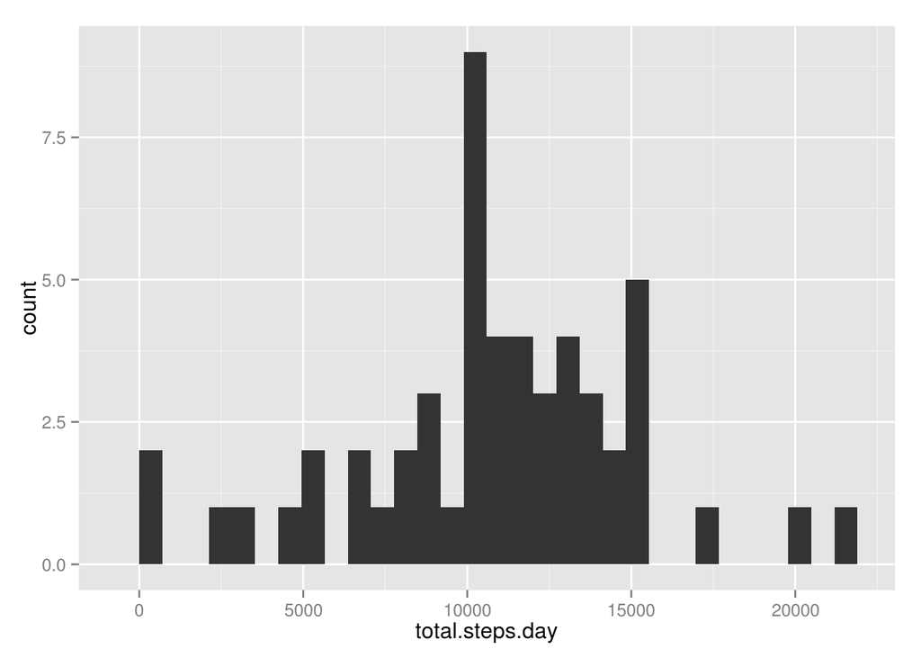

```r
library(ggplot2)
total.steps.day <- with(data, tapply(steps,date, sum))

mean.total.steps.day = mean(total.steps.day, na.rm = T)
median.total.steps.day = median(total.steps.day, na.rm = T)

qplot(total.steps.day, geom="histogram", binwidth = range(total.steps.day, na.rm =T)[2]/30)
```

The mean total number of steps taken per day are 10766 steps and the median of the total number of steps taken per day are 10765.

## What is the average daily activity pattern?

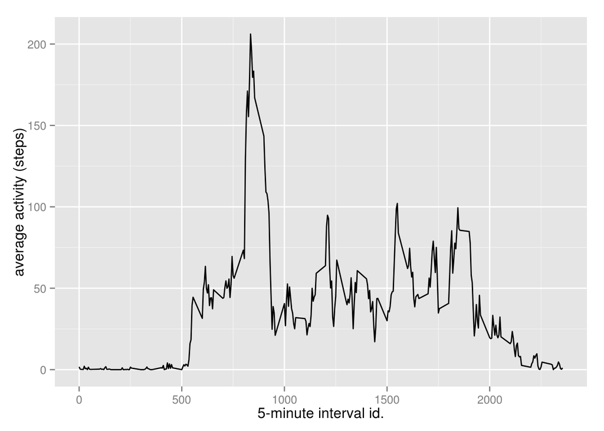

```r
daily.activity.pattern <- with(data, tapply(steps, interval, mean, na.rm = T))
df.daily.activity.pattern = data.frame( interval = as.numeric(names(daily.activity.pattern)), steps = daily.activity.pattern )

qplot(interval, steps, data = df.daily.activity.pattern, geom = c("line"),  ylab = "average activity (steps)", xlab = "5-minute interval id." )
```

```r
max_interval <- df.daily.activity.pattern[df.daily.activity.pattern$steps == max(daily.activity.pattern),]$interval
```

The maximum activity occurs at 835 5-min inteval id with average activity of 206.1698113 steps.

## Imputing missing values

The strategy to impute missing values uses the mean activity for the 5-minute interval that was missing.

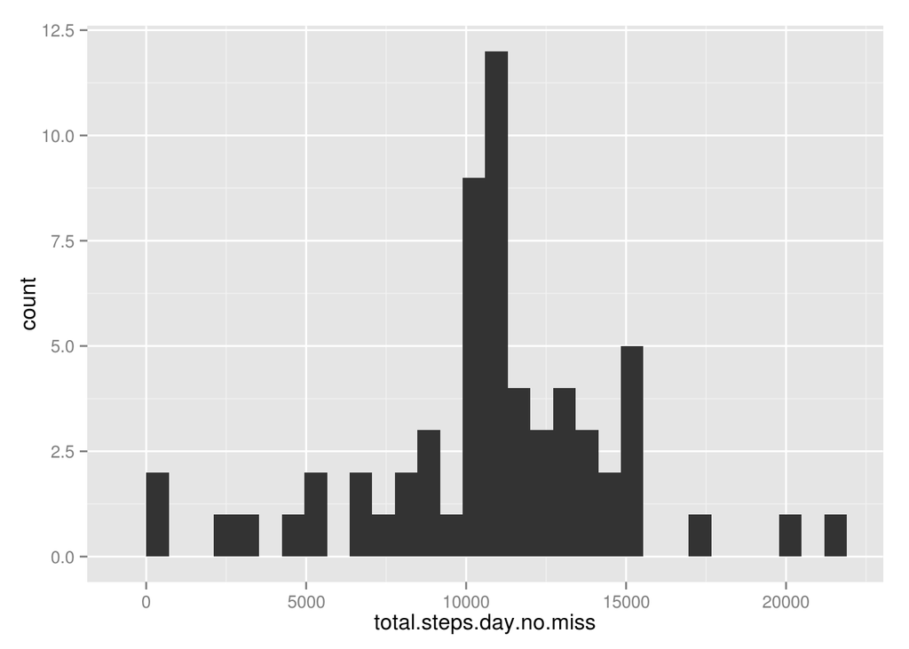

```r
total.number.of.rows.with.nas <- with(data, sum(is.na(interval) |is.na(steps) | is.na(date)) )

data.no.miss <- data
impute.fct <- function(id) { daily.activity.pattern[as.character(data[id,]$interval)]  }
missed <- subset(data,is.na(steps) )
missed.ids <- with(data,which(is.na(steps)))
data.no.miss[missed.ids,]$steps <- as.numeric(sapply(missed.ids, impute.fct ))

total.number.of.rows.with.nas.no.miss <- with(data.no.miss, sum(is.na(interval) |is.na(steps) | is.na(date)) )

total.steps.day.no.miss <- with(data.no.miss, tapply(steps,date, sum))

mean.total.steps.day.no.miss = mean(total.steps.day.no.miss)
median.total.steps.day.no.miss = median(total.steps.day.no.miss)

qplot(total.steps.day.no.miss, geom="histogram", binwidth = range(total.steps.day.no.miss, na.rm =T)[2]/30)
```

The total number of rows with NAs are 2304 rows. This is 13% of dataset rows.

After imputing the missing values with the mean we recalculate the previous measures. So, the mean total number of steps taken per day are 10766 steps and the median of the total number of steps taken per day are 10766.

The absolute difference between the means are of 0 steps and the absolute difference between the medians are of 1 steps.

## Are there differences in activity patterns between weekdays and weekends?

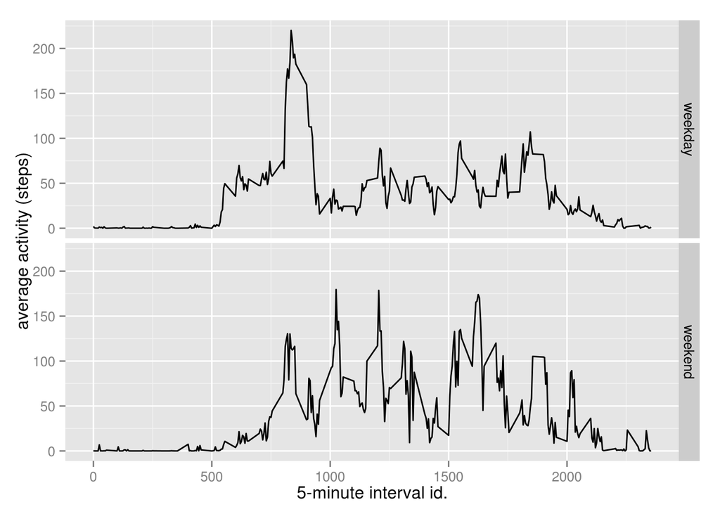

```r
data.no.miss$is.weekday <- factor(!(weekdays(data.no.miss$date) %in% c("Sunday","Saturnday")), c("TRUE","FALSE"),c("weekday","weekend"))


daily.activity.pattern.wd <- with(data.no.miss[data.no.miss$is.weekday =="weekday",], tapply(steps, interval, mean, na.rm = T))
daily.activity.pattern.we <- with(data.no.miss[data.no.miss$is.weekday =="weekend",], tapply(steps, interval, mean, na.rm = T))


dfwd = data.frame( interval = as.numeric(names(daily.activity.pattern.wd)), steps = daily.activity.pattern.wd, is.weekday = rep("weekday", length(daily.activity.pattern.wd))   )
dfwe = data.frame( interval = as.numeric(names(daily.activity.pattern.we)), steps = daily.activity.pattern.we, is.weekday = rep("weekend", length(daily.activity.pattern.we))   )

df <- rbind(dfwd,dfwe)

qplot(interval, steps, data = df, geom = c("line"), facets = is.weekday~., ylab = "average activity (steps)", xlab = "5-minute interval id." )
```

```r
max_interval.wd <- dfwd[dfwd$steps == max(daily.activity.pattern.wd),]$interval
max_interval.we <- dfwe[dfwe$steps == max(daily.activity.pattern.we),]$interval
```